# TrafficSignClassifier

## Step 0: Load The Data

```python
# Load pickled data
import cv2
import numpy as np
import pandas as pd
import tensorflow as tf
from tensorflow.contrib.layers import flatten
import pickle
import matplotlib.pyplot as plt
import seaborn as sns
from sklearn.utils import shuffle
%matplotlib inline
plt.rcParams["figure.figsize"] = 12, 10

training_file = 'data/train.p'
validation_file= 'data/test.p'
testing_file = 'data/valid.p'

with open(training_file, mode='rb') as f:
    train = pickle.load(f)
with open(validation_file, mode='rb') as f:
    valid = pickle.load(f)
with open(testing_file, mode='rb') as f:
    test = pickle.load(f)
```

## Step 1: Dataset Summary & Exploration

```python
### Replace each question mark with the appropriate value.
### Use python, pandas or numpy methods rather than hard coding the results

# TODO: Number of training examples
n_train = len(train['features'])

# TODO: Number of testing examples.
n_test = len(test['features'])

# TODO: What's the shape of an traffic sign image?
image_shape = train['features'][0].shape

# TODO: How many unique classes/labels there are in the dataset.
classes = set(train['labels'])
n_classes = len(classes)

print("Number of training examples =", n_train)
print("Number of testing examples =", n_test)
print("Image data shape =", image_shape)
print("Number of classes =", n_classes)
```

```
('Number of training examples =', 34799)
('Number of testing examples =', 4410)
('Image data shape =', (32, 32, 3))
('Number of classes =', 43)
```

### Step 1.1: Get an idea of original images size distribution and balance of classes in training set

[figure not shown]

```python
# classes_distribution = np.histogram(train['labels'], bins=100)
plt.rcParams['figure.figsize'] = 12,10
def get_class_distribution(labels):
    classes=[]
    for i in set(labels):
        classes.append(len(np.where(labels==i)[0]))
    return classes

olddist = get_class_distribution(train['labels'])
newdist = get_class_distribution(valid['labels'])
testdist = get_class_distribution(test['labels'])



fig = plt.figure()

ax1 = plt.subplot2grid((3,3), (0,0), colspan=1, rowspan=1)
ax2 = plt.subplot2grid((3,3), (0,1), colspan=1, rowspan=1)
ax3 = plt.subplot2grid((3,3), (0,2), colspan=1, rowspan=1)
fig.tight_layout()

ax1.bar(range(len(olddist)),olddist)
ax1.set_title('Validation set sample distribution')
ax1.set_xlabel('Class')
ax1.set_ylabel('Occurrence')

ax2.bar(range(len(newdist)), newdist)
ax2.set_title('Training set sample distribution')
ax2.set_xlabel('Class Number')
ax2.set_ylabel('Occurrence')

ax3.bar(range(len(testdist)), testdist)
ax3.set_title('Testing set sample distribution')
ax3.set_xlabel('Class Number')
ax3.set_ylabel('Occurrence')

plt.show()
```

### Step 1.2: Include an exploratory visualization of the dataset

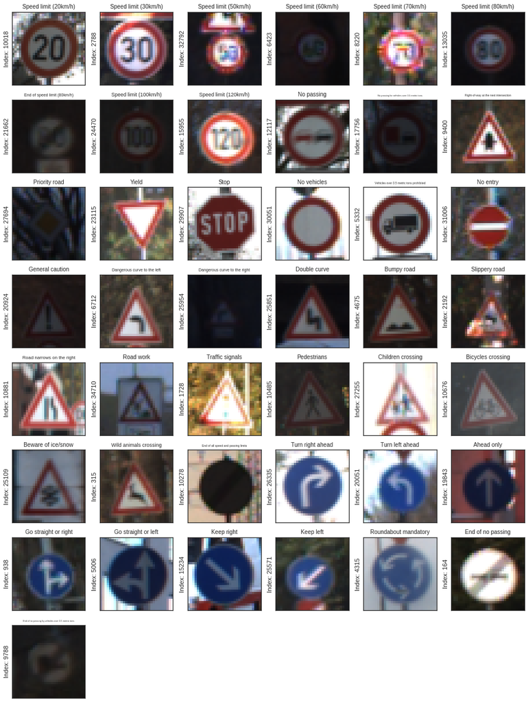

```python
def show_all_classes(features, labels, path_to_labels='data/signnames.csv'):

    classes = sorted(set(labels))
    df = pd.read_csv(path_to_labels)
    # fig = plt.figure()
    cols = 6
    rows = len(classes)/cols + 1 if (len(classes)%cols) else 0

    for row in range(rows):
        for col in range(cols):
            labelid = row * cols + col
            if labelid >= len(classes):
                break
            label = df.loc[labelid].SignName
            # Get the per-class indices in the training set
            class_indxs = np.where(labels==labelid)[0]
            # Pick at random an image from it
            if len(class_indxs) == 0:
                break
            rindx = class_indxs[np.random.randint(0,len(class_indxs))]
            # Get the image
            img = features[rindx]
            # Do the plotting
            with sns.axes_style("white"):
                plt.subplot(rows,cols,labelid+1)
                plt.imshow(img)
                plt.tick_params(
                    which='both', bottom='off', left='off', top='off', right='off', labelbottom='off', labelleft='off')
                plt.title(label, fontsize=200/(np.max([20,len(df.loc[labelid].SignName)])))
                plt.ylabel("Index: {}".format(rindx))
    # fig.tight_layout()
    plt.show()

plt.rcParams["figure.figsize"] = 16, 22
show_all_classes(train['features'], train['labels'])
```

## Step 2: Design and Test a Model Architecture

Design and implement a deep learning model that learns to recognize traffic signs. Train and test your model on the [German Traffic Sign Dataset](http://benchmark.ini.rub.de/?section=gtsrb&subsection=dataset).

The LeNet-5 implementation shown in the classroom at the end of the CNN lesson is a solid starting point. You'll have to change the number of classes and possibly the preprocessing, but aside from that it's plug and play!

With the LeNet-5 solution from the lecture, you should expect a validation set accuracy of about 0.89. To meet specifications, the validation set accuracy will need to be at least 0.93. It is possible to get an even higher accuracy, but 0.93 is the minimum for a successful project submission.

There are various aspects to consider when thinking about this problem:

- Neural network architecture (is the network over or underfitting?)
- Play around preprocessing techniques (normalization, rgb to grayscale, etc)
- Number of examples per label (some have more than others).
- Generate fake data.

Here is an example of a [published baseline model on this problem](http://yann.lecun.com/exdb/publis/pdf/sermanet-ijcnn-11.pdf). It's not required to be familiar with the approach used in the paper but, it's good practice to try to read papers like these.

### Step 2.1: Preproces: Surrogate Data Generation

Minimally, the image data should be normalized so that the data has mean zero and equal variance. For image data, `(pixel - 128)/ 128` is a quick way to approximately normalize the data and can be used in this project.

Other pre-processing steps are optional. You can try different techniques to see if it improves performance.

Use the code cell (or multiple code cells, if necessary) to implement the first step of your project.

#### Step 2.1.1: Image transformation methods

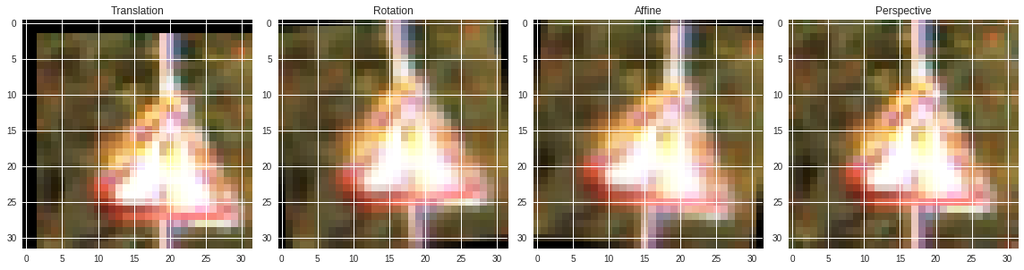

```python
# Preprocessing steps

def whiten_image(img, N=100, eps=1e-5):
    """
    PCA based whitening based on extracting the first N principal components
    and reconstructing back the image
    source: http://cs231n.github.io/neural-networks-2/
    """
    img = img.astype(np.float32)
    output = np.zeros_like(img, dtype=np.float64)
    for d in range(img.shape[2]):
        # Per-Channel PCA whitening
        X = img[:,:,d].copy()
        # Centre data around 0
        X -= np.mean(X, axis=0)
        # Estimate covariance matrix
        cov = np.dot(X.T, X) / X.shape[0]
        U,S,V = np.linalg.svd(cov)
        Xrot = np.dot(X, U)
        # Take the first (N) Principal Components
        Xrot_reduced = np.dot(X, U[:,:N])
        Xwhite = Xrot / np.sqrt(S + eps)
        X -= X.min()
        X /= X.max()
        output[:,:,d] = X
    return output

def gray(data):
    output = []
    for img in data:
        output.append(cv2.cvtColor(img, cv2.COLOR_RGB2GRAY))
    return np.array(output, np.float32)

def normalize(data, val=255):
    data = data.astype(np.float32)
    data -= data.min()
    data /= data.max()
    return data

def blur(data,kernel_size=3):
    output = []
    for img in data:
        output.append(cv2.GaussianBlur(img, (kernel_size, kernel_size), 0))
    return np.array(output, np.float32)

def yuv(data):
    output = []
    for img in data:
        output.append(cv2.cvtColor(img, cv2.COLOR_RGB2YUV))
    return np.array(output, np.float32)

def rotate(img, centre=None):
    """
    Rotation about a centre point (default==image centre)
    """
    rows,cols = img.shape[:2]
    if centre is None:
        centre = (cols//2,rows//2)
    degrees = np.random.randint(6,9,1)[0]
    degrees *= -1 if (np.random.rand() < 0.5) else 1
    M = cv2.getRotationMatrix2D(centre,degrees,1)
    return cv2.warpAffine(img,M,(cols,rows))

def translate(img):
    """
    Linear translation
    """
    x,y = np.random.randint(-3,3,2)
    (cols,rows) = img.shape[:2]
    M = np.float32([[1,0,x],[0,1,y]])
    return cv2.warpAffine(img,M,(cols,rows))

def affine(img):
    """
    Affine transformation based on two sets of 3-points
    """
    rows,cols = img.shape[:2]
    pts1 = np.float32([[5,5],[16,16],[5,20]])
    pts2 = np.float32([[4,6],[16,16],[6,21]])
    if np.random.rand()>0.5:
        M = cv2.getAffineTransform(pts1,pts2)
    else:
        M = cv2.getAffineTransform(pts2,pts1)
    return cv2.warpAffine(img,M,(cols,rows))


def inward_perspective(img):
    """
    Randomly warp the image inwards
    """
    rows,cols = img.shape[:2]
    x,y = np.random.randint(0,6,2)
    pts = np.float32([
        [0,0],
        [rows,-x],
        [0,cols],
        [rows,cols + y]
    ])
    edges = np.float32([
        [0,0],
        [rows,0],
        [0,cols],
        [rows,cols]
    ])
    M = cv2.getPerspectiveTransform(pts, edges)
    return cv2.warpPerspective(img,M,(rows, cols))

def fill(img):
    """
    Fill up empty pixels due to perturbation with mean channel values
    """
    channels = cv2.split(img)
    for indx, channel in enumerate(channels):
        channel[np.where(channel==0)] = np.mean(channel)
        img[:,:,indx] = channel
    return img

def batch_operate_on_data(train_test_valid_batch, operation):
    """
    Input a list of (N,fx,fy,ch) arrays and iterate through all of them
    applying the given operation
    """
    output_data = []
    for data in train_test_valid_batch:
        output_data.append(operation(data))
    return output_data

# Test the above transforms
img = train['features'][np.random.randint(0,10000,1)[0]]

fig = plt.figure()

ax1 = plt.subplot2grid((4,4), (0,0), colspan=1, rowspan=1)
ax2 = plt.subplot2grid((4,4), (0,1), colspan=1, rowspan=1)
ax3 = plt.subplot2grid((4,4), (0,2), colspan=1, rowspan=1)
ax4 = plt.subplot2grid((4,4), (0,3), colspan=1, rowspan=1)

ax1.imshow(translate(img))
ax1.set_title('Translation')

ax2.imshow(rotate(img))
ax2.set_title('Rotation')

ax3.imshow(affine(img))
ax3.set_title('Affine')

ax4.imshow(inward_perspective(img))
ax4.set_title('Perspective')

fig.tight_layout()

plt.show()
```

#### Step 2.1.1: Class-Balancing Method

```python
def balance_classes_out(features, labels, threshold='median', operations=[]):
    """
    Sample distribution balancing by setting the lowest class counts to the 'threshold' of
    the original set. The newly generated images are perturbed by the operations specified
    in the operations list.

    Inputs:
        features:    np.ndarray of images
        labels:      np.ndarray of labels
        threshold:   balancing threshold (target sample counts per class)
            options: median (default), mean, max
        operations:  Operations to be used for new image generation
            options: [rotate, affine, translate] or any of the set

    Outputs:
        features:    np.ndarray: images + newly generated images
        labels:      np.ndarray: labels + newly generated labels
    """
    o_features = features.astype(np.float64).tolist()
    o_labels = labels.tolist()

    l_operations = len(operations)
    class_counts = get_class_distribution(labels)
    if 'median' in threshold:
        target_level = np.median(class_counts)
    elif 'mean' in threshold:
        target_level = np.mean(class_counts)
    elif 'max' in threshold:
        target_level = np.max(class_counts)
    else:
        # default level is the median
        target_level = np.median(class_counts)

    to_be_expanded = np.where(class_counts < target_level)[0]
    niter=0
    for clslabel in to_be_expanded:
        iterations = int(target_level - class_counts[clslabel]) / l_operations
        niter+=iterations
        clsindxs = np.where(labels == clslabel)[0]
        for it in range(iterations):
            rindxs = np.random.randint(clsindxs.min(), clsindxs.max(), l_operations)
            imgs = features[rindxs]
            for indx, operation in enumerate(operations):
#                 img = fill(operation(imgs[indx]))
#                 o_features = np.vstack([o_features, np.expand_dims(img, 0)])
#                 o_labels = np.hstack([o_labels, clslabel])
                o_features.append(fill(operation(imgs[indx])))
                o_labels.append(clslabel)
    return np.array(o_features, np.float32), np.array(o_labels, np.int)
```

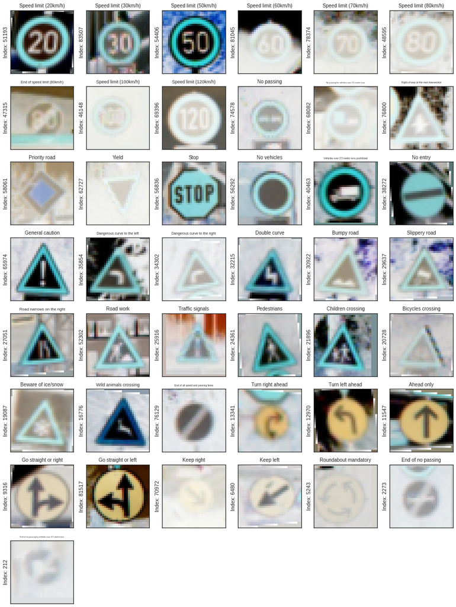

```python
X_train, y_train = balance_classes_out(
    train['features'],
    train['labels'],
    threshold='maxbalanced',
    operations=[translate, affine, inward_perspective])
# Show results
plt.rcParams["figure.figsize"] = 16, 22
show_all_classes(np.flip(X_train, 0), np.flip(y_train, 0))
```

### 2.1: Preprocessing Results

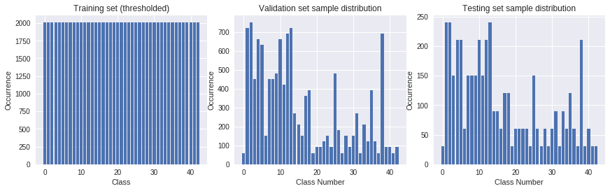

```python
# classes_distribution = np.histogram(train['labels'], bins=100)
labels = y_train
plt.rcParams['figure.figsize'] = 12,10
def get_class_distribution(labels):
    classes=[]
    for i in set(labels):
        classes.append(len(np.where(labels==i)[0]))
    return classes

olddist = get_class_distribution(y_train)
newdist = get_class_distribution(valid['labels'])
testdist = get_class_distribution(test['labels'])

fig = plt.figure()

ax1 = plt.subplot2grid((3,3), (0,0), colspan=1, rowspan=1)
ax2 = plt.subplot2grid((3,3), (0,1), colspan=1, rowspan=1)
ax3 = plt.subplot2grid((3,3), (0,2), colspan=1, rowspan=1)
fig.tight_layout()

ax1.bar(range(len(olddist)),olddist)
ax1.set_title('Training set (thresholded)')
ax1.set_xlabel('Class')
ax1.set_ylabel('Occurrence')

ax2.bar(range(len(newdist)), newdist)
ax2.set_title('Validation set sample distribution')
ax2.set_xlabel('Class Number')
ax2.set_ylabel('Occurrence')

ax3.bar(range(len(testdist)), testdist)
ax3.set_title('Testing set sample distribution')
ax3.set_xlabel('Class Number')
ax3.set_ylabel('Occurrence')

plt.show()
```

### 2.2 Preprocess: Grayscale and Normalization

```python
X_train, X_test, X_valid = batch_operate_on_data(
    (
        np.array(X_train, np.uint8),
        test['features'],
        valid['features']
    ),
    gray
)

X_train, X_test, X_valid = batch_operate_on_data(
    (
        X_train,
        X_test,
        X_valid,
    ),
    normalize
)

shape = X_train[0].shape
if len(shape) < 4:
    X_train = np.expand_dims(X_train,-1)
    X_test = np.expand_dims(X_test,-1)
    X_valid = np.expand_dims(X_valid,-1)

n_channels = X_train.shape[-1]

X_train, y_train = shuffle(X_train, y_train)
# X_train, y_train = shuffle(X_train, train['labels'])
X_test, y_test = shuffle(X_test, test['labels'])
X_valid, y_valid = shuffle(X_valid, valid['labels'])
```

### 2.3 Model Architecture

```python
mu = 0.01
sigma = 0.01

def tfvar(shape, mu=mu, sigma=sigma, init_type='normal'):
    """
    Equivalent initialization as in LeNet
    """
    return tf.Variable(tf.truncated_normal(shape=shape, mean=mu, stddev=sigma))

def tfhe(shape):
    """
    "Delving Deep into Rectifiers:Surpassing Human-Level Performance on ImageNet Classification"
    arXiv:1502.01852v1  [cs.CV]  6 Feb 2015
    """
    return tf.Variable(tf.random_normal(shape) * tf.sqrt(tf.constant(2.0/np.sum(shape), dtype=tf.float32)))

layers = {}
layers.update({
    'c1':{
        'd': n_channels * 9,
        'fx': 5,
        'fy': 5
    }
})
layers.update({
    'c2':{
        'd': layers['c1']['d'] * 6,
        'fx': 5,
        'fy': 5
    }
})
layers.update({
    'c3':{
        'd': layers['c2']['d'] * 4,
        'fx': 5,
        'fy': 5
    }
})
layers.update({
    'f0': {
        # Resulting flat size = n_channels * 9 * 6 * 4 = 1 * 9 * 6 * 4 = 216
        'in': layers['c3']['d'],
        'out': 480
    }
})
layers.update({
    'f1': {
        'in': layers['f0']['out'],
        'out': 240
    }
})
layers.update({
    'f2': {
        'in': layers['f1']['out'],
        'out': 43
    }
})

weights = {
    'wc1': tfhe((layers['c1']['fx'], layers['c1']['fy'], n_channels, layers['c1']['d'])),
    'wc2': tfhe((layers['c2']['fx'], layers['c2']['fy'], layers['c1']['d'], layers['c2']['d'])),
    'wc3': tfhe((layers['c3']['fx'], layers['c3']['fy'], layers['c2']['d'], layers['c3']['d'])),
    'wf0': tfhe((layers['f0']['in'], layers['f0']['out'])),
    'wf1': tfhe((layers['f1']['in'], layers['f1']['out'])),
    'wf2': tfhe((layers['f2']['in'], layers['f2']['out']))
}

biases = {
    'bc1': tf.Variable(tf.zeros(layers['c1']['d'])),
    'bc2': tf.Variable(tf.zeros(layers['c2']['d'])),
    'bc3': tf.Variable(tf.zeros(layers['c3']['d'])),
    'bf0': tf.Variable(tf.zeros(layers['f0']['out'])),
    'bf1': tf.Variable(tf.zeros(layers['f1']['out'])),
    'bf2': tf.Variable(tf.zeros(layers['f2']['out']))
}

def conv2d(x, W, b, strides=1, pad='VALID'):
    # Conv2D wrapper, with bias and relu activation
    x = tf.nn.conv2d(x, W, strides=[1, strides, strides, 1], padding=pad)
    x = tf.nn.bias_add(x, b)
    x = tf.nn.relu(x)
#     print("Size after conv2d: {}".format(x.shape))
    return x

def avgpool(x, k=2, pad='VALID'):
    x = tf.nn.avg_pool(x, ksize=[1, k, k, 1], strides=[1, k, k, 1], padding=pad)
#     print("Size after avgpool: {}".format(x.shape))
    return x

def fullcon(x, W, b):
    fc = tf.matmul(x, W)
    fc = tf.nn.bias_add(fc, b)
    fc = tf.nn.relu(fc)
    return fc

def LeNet(x, weights, biases, dropout=0.5):
    conv1 = conv2d(x, weights['wc1'], biases['bc1'])
    conv1 = avgpool(conv1, k=2)
    conv2 = conv2d(conv1, weights['wc2'], biases['bc2'])
    conv2 = avgpool(conv2, k=2)
    conv3 = conv2d(conv2, weights['wc3'], biases['bc3'])
    conv3 = avgpool(conv3, k=1)
    fc0   = flatten(conv3)
    fc1   = fullcon(fc0, weights['wf0'], biases['bf0'])
    fc1   = tf.nn.dropout(fc1, dropout)
    fc2   = fullcon(fc1, weights['wf1'], biases['bf1'])
    fc2   = tf.nn.dropout(fc2, dropout)
    logits = tf.matmul(fc2, weights['wf2']) + biases['bf2']
    return logits

x = tf.placeholder(tf.float32, (None, 32, 32, n_channels))
logits = LeNet(x, weights, biases)
config = tf.ConfigProto(
    device_count={'GPU': 1}, # set GPU to 0 to force on CPU
)
config.gpu_options.allow_growth = True

with tf.Session(config=config) as sess:
    sess.run(tf.global_variables_initializer())
    out = sess.run(logits, feed_dict={x:X_train[:1]})
print out.shape
print out
```

```
(1, 43)
[[  2.69879580e-01   4.66319650e-01  -9.61673856e-01   3.13263178e-01
   -7.80264378e-01  -1.47745621e+00   2.77310038e+00   2.00165248e+00
    2.90862322e-01   1.43471134e+00   2.91129088e+00   9.13926959e-01
   -3.34471703e-01  -3.46515685e-01   2.30436027e-01   1.81189942e+00
   -2.49373257e-01   1.02092683e+00   2.26892009e-02  -2.04671907e+00
   -1.52619338e+00  -1.69527173e-01  -6.24761224e-01  -2.44475886e-01
    3.22121322e-01  -6.71561241e-01   1.28081590e-02  -1.49765885e+00
   -6.46131754e-01   3.08573902e-01  -3.57147783e-01   7.34532058e-01
    2.59152651e+00   3.82089525e-01   1.04268812e-01  -1.31142497e-01
    2.06522942e-02   7.89925396e-01   1.41704589e-01  -2.15786695e-03
   -1.78320706e+00   4.21332628e-01  -3.88761088e-02]]
```

### Train, Validate and Test the Model

A validation set can be used to assess how well the model is performing. A low accuracy on the training and validation sets imply underfitting. A high accuracy on the training set but low accuracy on the validation set implies overfitting.

```python
runs = []
```

```
Training on 86429 samples
()
EPOCH 1
Validation Accuracy = 0.814
()
EPOCH 2
Validation Accuracy = 0.873
()
EPOCH 3
Validation Accuracy = 0.881
()
EPOCH 4
Validation Accuracy = 0.889
()
EPOCH 5
Validation Accuracy = 0.894
()
EPOCH 6
Validation Accuracy = 0.906
()
EPOCH 7
Validation Accuracy = 0.899
()
EPOCH 8
Validation Accuracy = 0.913
()
EPOCH 9
Validation Accuracy = 0.914
()
EPOCH 10
Validation Accuracy = 0.916
()
EPOCH 11
Validation Accuracy = 0.923
()
EPOCH 12
Validation Accuracy = 0.915
()
EPOCH 13
Validation Accuracy = 0.924
```

[output cut: 98 more lines]

```
Validation Accuracy = 0.927
()
EPOCH 47
Validation Accuracy = 0.939
()
EPOCH 48
Validation Accuracy = 0.942
()
EPOCH 49
Validation Accuracy = 0.945
()
EPOCH 50
Validation Accuracy = 0.931
()
Model saved
```

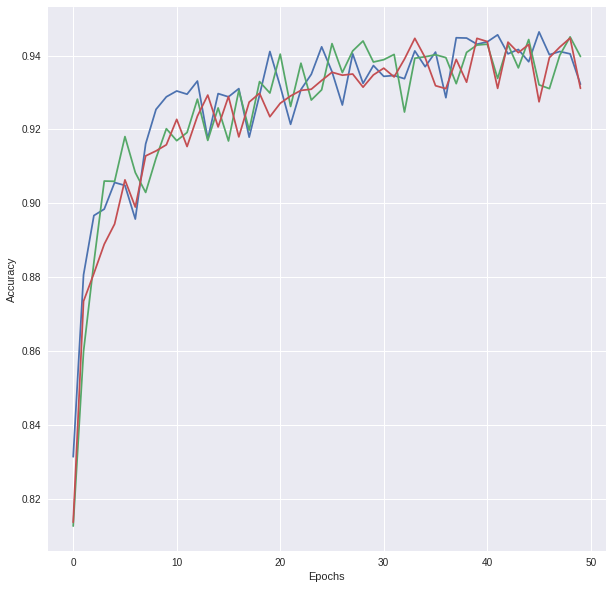

```python
vacc = []
rate = 0.0007
EPOCHS = 50
BATCH_SIZE=128
dropout=0.85
x = tf.placeholder(tf.float32, (None, 32, 32, n_channels))
y = tf.placeholder(tf.int32, (None))
keep_prob = tf.placeholder(tf.float32)
one_hot_y = tf.one_hot(y, n_classes)

# logits = LeNet(x, dropout=dropout)
logits = LeNet(x, weights, biases, dropout=dropout)
cross_entropy = tf.nn.softmax_cross_entropy_with_logits(labels=one_hot_y,logits=logits)
loss_operation = tf.reduce_mean(cross_entropy)
optimizer = tf.train.AdamOptimizer(learning_rate = rate)
training_operation = optimizer.minimize(loss_operation)

correct_prediction = tf.equal(tf.argmax(logits, 1), tf.argmax(one_hot_y, 1))
accuracy_operation = tf.reduce_mean(tf.cast(correct_prediction, tf.float32))
saver = tf.train.Saver()

def evaluate(X_data, y_data, dropout):
    num_examples = len(X_data)
    total_accuracy = 0
    sess = tf.get_default_session()
    for offset in range(0, num_examples, BATCH_SIZE):
        batch_x, batch_y = X_data[offset:offset+BATCH_SIZE], y_data[offset:offset+BATCH_SIZE]
        accuracy = sess.run(accuracy_operation, feed_dict={x: batch_x, y: batch_y, keep_prob: dropout})
        total_accuracy += (accuracy * len(batch_x))
    return total_accuracy / num_examples

def real_data_eval(data):
    sess = tf.get_default_session()
    output = sess.run(logits, feed_dict={x: data, keep_prob: 1})
    return np.argmax(output, 1)

config = tf.ConfigProto(
    device_count={'GPU': 1}
)
config.gpu_options.allow_growth = True

with tf.Session(config=config) as sess:
    sess.run(tf.global_variables_initializer())
    num_examples = len(X_train)

    print("Training on {} samples".format(num_examples))
    print()
    for i in range(EPOCHS):
        X_train, y_train = shuffle(X_train, y_train)
        for offset in range(0, num_examples, BATCH_SIZE):
            end = offset + BATCH_SIZE
            batch_x, batch_y = X_train[offset:end], y_train[offset:end]
            sess.run(training_operation, feed_dict={x: batch_x, y: batch_y, keep_prob: dropout})

        validation_accuracy = evaluate(X_valid, y_valid, 1)
        vacc.append(validation_accuracy)
        print("EPOCH {}".format(i+1))
        print("Validation Accuracy = {:.3f}".format(validation_accuracy))
        print()

    saver.save(sess, './lenets')
    print("Model saved")

runs.append(vacc)
for r in runs:
    plt.plot(r)
    plt.ylabel('Accuracy')
    plt.xlabel('Epochs')
# Best so far 0.965
```

```python
# Test Model
with tf.Session() as sess:
    saver.restore(sess, tf.train.latest_checkpoint('.'))
    test_accuracy = evaluate(X_test, y_test, 1)
    print("Test Accuracy = {:.3f}".format(test_accuracy))
```

```
Test Accuracy = 0.956
```

## Step 3: Test a Model on New Images

To give yourself more insight into how your model is working, download at least five pictures of German traffic signs from the web and use your model to predict the traffic sign type.

You may find `signnames.csv` useful as it contains mappings from the class id (integer) to the actual sign name.

### Load and Output the Images and their predictions

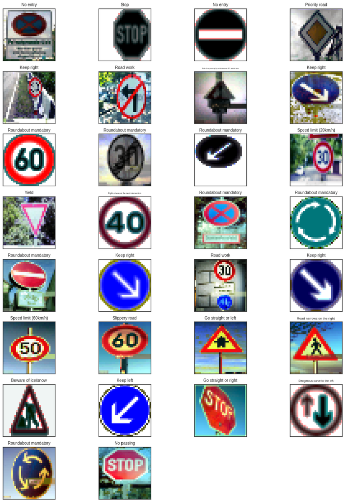

```python
import os
img_path='data/de_traffic_signs/'
imsize = (32,32)
dimgs = {}
for img_file in os.listdir(img_path):
    img = cv2.imread(os.path.join(img_path, img_file))
    img = cv2.GaussianBlur(img, (17,17), 0)
    img = cv2.merge([cv2.equalizeHist(img[:,:,0]),cv2.equalizeHist(img[:,:,1]),cv2.equalizeHist(img[:,:,2])])
    img = cv2.resize(img, imsize, cv2.INTER_CUBIC)
    img = cv2.cvtColor(img, cv2.COLOR_BGR2RGB)
    dimgs.update({img_file: img})

imgs = np.array([dimgs[img] for img in dimgs]).reshape(len(dimgs),imsize[0],imsize[1],3)

def show_new_entries(features, labels, cols=4):
    df = pd.read_csv('data/signnames.csv')
    rows = np.ceil(len(labels) / float(cols))
    for indx, (label, img) in enumerate(zip(labels,features)):
        row, col = indx//cols, indx%cols
        with sns.axes_style("white"):
            plt.subplot(rows,cols,indx+1)
            plt.imshow(img)
            plt.tick_params(
                which='both', bottom='off', left='off', top='off', right='off', labelbottom='off', labelleft='off')
            plt.title(df.loc[label].SignName, fontsize=200/(np.max([20,len(df.loc[label].SignName)])))

def real_data_eval(X_data, dropout=1.0):
    sess = tf.get_default_session()
    out = sess.run(logits, feed_dict={x: X_data, keep_prob: dropout})
    return np.argmax(out, 1)

def get_labels(data):
    with tf.Session() as sess:
        X = normalize(gray(data.copy()))
        X = np.expand_dims(X, -1)
        saver.restore(sess, tf.train.latest_checkpoint('.'))
        output = real_data_eval(X, 1)
    return output

plt.rcParams['figure.figsize'] = 16,22
X = shuffle(imgs)
labels = get_labels(X)
show_new_entries(X, labels, cols=4)
```

### Analyze Performance

```python
### Calculate the accuracy for these 5 new images.
detect_ok = 9.0
print("Error Rate for number of samples({n_samples}): {error}".format(
    n_samples=int(len(imgs)), error=(detect_ok/len(imgs))))
### For example, if the model predicted 1 out of 5 signs correctly, it's 20% accurate on these new images.
```

[output not shown]

### Output Top 5 Softmax Probabilities For Each Image Found on the Web

```python
def get_top_k_softmax(data, k=5):
    with tf.Session() as sess:
        X = normalize(gray(data.copy()))
        X = np.expand_dims(X, -1)
        saver.restore(sess, tf.train.latest_checkpoint('.'))
        prediction = sess.run(logits, feed_dict={x: X, keep_prob: dropout})
        top_5 = sess.run(tf.nn.top_k(tf.nn.softmax(prediction), k=k))

    df = pd.read_csv('data/signnames.csv')
    labels = get_labels(imgs)

    fmt = "".join([
        "{label:<8}", "{string:<40}", "{prob:<16}", "{predictions:<100}"
    ])
    hdr = {
        "label": "#",
        "string": "Label ",
        "prob": "Probability",
        "predictions": "Top 5 Predictions",
    }
    print fmt.format(**hdr)
    for label, prob, top in zip(labels, top_5.values, top_5.indices):
        print(fmt.format(label=label, string=df.loc[label].SignName, prob=prob[0], predictions=top))

get_top_k_softmax(imgs)
```

```
#       Label                                   Probability     Top 5 Predictions
40      Roundabout mandatory                    0.961037933826  [38 36 13 40 25]
23      Slippery road                           0.993301868439  [23 17 36 11  0]
9       No passing                              0.988853812218  [ 9 41 12 38 28]
38      Keep right                              1.0             [38 25 10 23 29]
17      No entry                                1.0             [17 40 11 16 10]
40      Roundabout mandatory                    0.551129817963  [40 25  1 11  3]
16      Vehicles over 3.5 metric tons prohibited0.693986833096  [16 40 11 23 33]
38      Keep right                              1.0             [38 18 23 25 34]
19      Dangerous curve to the left             0.999999761581  [19 21 37 33 39]
39      Keep left                               1.0             [39 28 33 19 11]
40      Roundabout mandatory                    0.998993337154  [40 12 14  8  9]
40      Roundabout mandatory                    0.668724060059  [38 40 12 14 17]
30      Beware of ice/snow                      0.886103749275  [30 40 11 37 28]
17      No entry                                1.0             [17  0  1  2  3]
```

[output cut: 16 more lines]

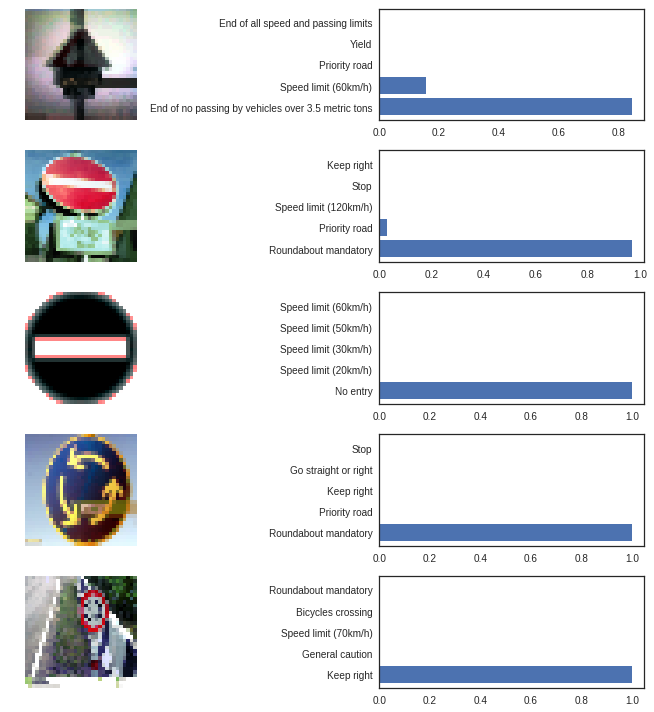

```python
def show_top_k_predictions(data, k=5):
    with tf.Session() as sess:
        X = normalize(gray(data.copy()))
        X = np.expand_dims(X, -1)
        saver.restore(sess, tf.train.latest_checkpoint('.'))
        prediction = sess.run(logits, feed_dict={x: X, keep_prob: dropout})
        top_k = sess.run(tf.nn.top_k(tf.nn.softmax(prediction), k=k))

    df = pd.read_csv('data/signnames.csv')
    labels = get_labels(imgs)

    plt.rcParams['figure.figsize'] = (2*k, 2*k)
    top_5_imgs = np.random.randint(0,len(imgs), k)
    for indx, img in enumerate(top_5_imgs):
        with sns.axes_style("white"):
            plt.subplot(len(top_5_imgs), 2, (2*indx)+1)
            plt.imshow(np.squeeze(imgs[img]), cmap='gray')
            plt.axis('off')
            plt.subplot(len(top_5_imgs) ,2, (2*indx)+2)
            plt.barh(np.arange(k), top_k.values[img])
            plt.yticks(np.arange(k), df.loc[top_k.indices[img]].SignName)
            plt.tight_layout()

show_top_k_predictions(imgs, k=5)
```